# A Practical Guide to Make AI Explainable

### with FlashTorch

Misa Ogura

Research Software Engineer @ BBC R&D

📡 Slide deck @ **tinyurl.com/flashtorch-wddconf**

## Hello 👋

[figure not shown]

- From Tokyo, based in London
- Cancer Cell Biologist
- Research Software Engineer
- Co-Founder & CTO of Women Driven Development

## Explainability & AI

What is it and why is it important?

## Explainability

Ability to **explain** why a system behaves the way it does.

Interpretability: can you *predict* an outcome, not (necessarily) knowing why?

e.g. Driving a car:

- I *know if* I steer to the left, *then* the car turns left == **Interpretability**
- I can *explain* why that is (i.e. physical mechanics behind it) == **Explainability**

**In the context of AI:**

Ability to explain decisions made by algorithms.

*But what do I mean by AI?*

## Deep learning

A subset of machine learning in AI

Uses **deep neural networks** to extract patterns in data.

[figure not shown]

Millions of parameters: *notoriously difficult* to explain.

Applications in computer vision, natural language processing, reinforcement learning...

## Case of Joy Buolamwini

*Hi camera, I've got a face. Can you see my face?*

[figure not shown]

[Source](https://www.youtube.com/watch?v=UG_X_7g63rY)

## Explainability is important

Sadly biases *do* creep into the algorithms.

Being able to **spot, understand & explain** is the first step!

## Convolutional neural network (CNN)

Recent breakthrough in computer vision

## Convolution

Image processing technique

**Detects features** such as edges and curves.

Features are *pre-defined*.

[figure not shown]

[Source](http://setosa.io/ev/image-kernels/)

## CNN

Convolution + deep neural network

Useful features are *learned* during training, rather than pre-defined.

[figure not shown]

How can we explain output from the CNN?

[Source](https://missinglink.ai/guides/convolutional-neural-networks/convolutional-neural-network-tutorial-basic-advanced/)

## Feature visualization

"Looking through the eyes" of the neural nets

## How do CNNs *perceive* images?

[Brilliant](https://distill.pub/2017/feature-visualization/) [series](https://distill.pub/2018/building-blocks/) of [articles](https://distill.pub/2019/activation-atlas/) on Distill.

[figure not shown]

## Saliency maps

What is most noticeable/important?

- Saliency: a subjective quality in human visual perception
- Makes certain regions *stand out*

**Saliency maps** in computer vision highlight salient regions.

[figure not shown]

[Source](https://www.mathworks.com/matlabcentral/fileexchange/43558-roi-selection-for-saliency-maps)

## Saliency maps for CNN

Gives some intuition of *attention*

- First [Introduced](https://arxiv.org/abs/1312.6034) in 2013
- Calculates the *relationship* (or gradients) between output label & input image
- **Positive gradients == positive effects** on the confidence of the label

[figure not shown]

Great!

How can I do this with *my* network? 🤨

[Source](https://missinglink.ai/guides/convolutional-neural-networks/convolutional-neural-network-tutorial-basic-advanced)

## FlashTorch to the rescue!

[Open source](https://github.com/MisaOgura/flashtorch) feature visualization toolkit

- Compatible with [PyTorch](https://pytorch.org/)
- Supports [torchvision models](https://pytorch.org/docs/stable/torchvision/models.html) & custom PyTorch models
- Available to install via pip

  ```
    $ pip install flashtorch
  ```

## FlashTorch demo 1

### Visualizing saliency maps

### Prepare an input 🐦

```
Before: <class 'PIL.Image.Image'>
After: <class 'torch.Tensor'>, torch.Size([1, 3, 224, 224])
```

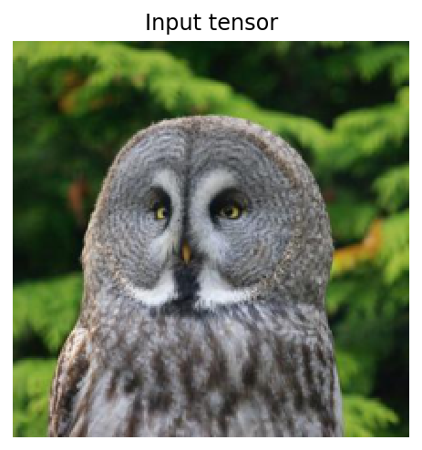

```python
from flashtorch.utils import load_image, apply_transforms, denormalize, format_for_plotting

image = load_image('../../examples/images/great_grey_owl.jpg')

owl = apply_transforms(image)

print(f'Before: {type(image)}')
print(f'After: {type(owl)}, {owl.shape}')

plt.imshow(format_for_plotting(denormalize(owl)))
plt.title('Input tensor')
plt.axis('off');
```

### Create a `Backprop` object

```python
from flashtorch.saliency import Backprop

model = models.alexnet(pretrained=True)

backprop = Backprop(model)
```

- Registers **custom functions** to model layers
- Grabs gradients out of the computational graph

[figure not shown]

[Source](https://missinglink.ai/guides/convolutional-neural-networks/convolutional-neural-network-tutorial-basic-advanced)

### Visualize saliency maps

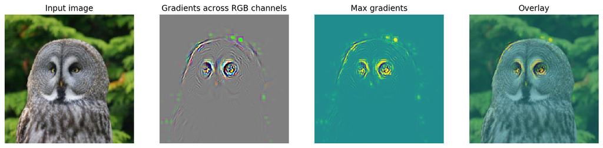

```python
from flashtorch.utils import ImageNetIndex

imagenet = ImageNetIndex()
target_class = imagenet['great grey owl']

backprop.visualize(owl, target_class, guided=True)
```

Pixels around the **head and eyes** have the strongest positive effects.  
What about other birds?

### What makes peacock a peacock?

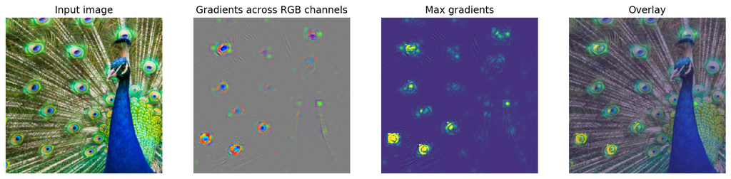

```python
peacock = apply_transforms(load_image('../../examples/images/peacock.jpg'))
target_class = imagenet['peacock']

backprop.visualize(peacock, target_class, guided=True)
```

### ... or a toucan?

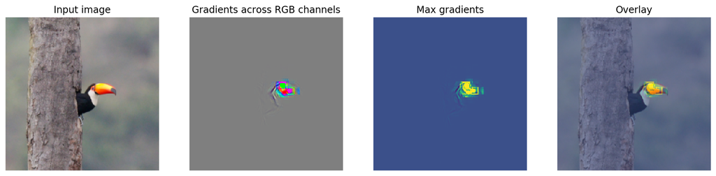

```python
toucan = apply_transforms(load_image('../../examples/images/toucan.jpg'))
target_class = imagenet['toucan']

backprop.visualize(toucan, target_class, guided=True)
```

Do you agree? 🤖  
What about when it gets things wrong?  
Is FlashTorch still useful?

## FlashTorch demo 2

### When neural nets get things wrong

### Transfer learning

A form of knowledge transfer

A model developed for one task is *reused as a starting point* for another.

[figure not shown]

[Source](https://software.intel.com/en-us/articles/use-transfer-learning-for-efficient-deep-learning-training-on-intel-xeon-processors)

### Building a flower classifier

1. Get a model, pre-trained with the ImageNet dataset (1000 classes)
2. Swap out the last layer (102 classes) --> *Un-tuned*
3. Train with a [flower dataset](http://www.robots.ox.ac.uk/~vgg/data/flowers/102/index.html) --> *Tuned*

Un-tuned model: **0.1%** accuracy on the test dataset 😅

*Why* is it so bad? Let's take a look.

[figure not shown]

```python
plt.imshow(load_image('images/foxgloves.jpg'))
plt.title('Foxgloves')
plt.axis('off');
```

### Un-tuned model

Test accuracy: 0.1%

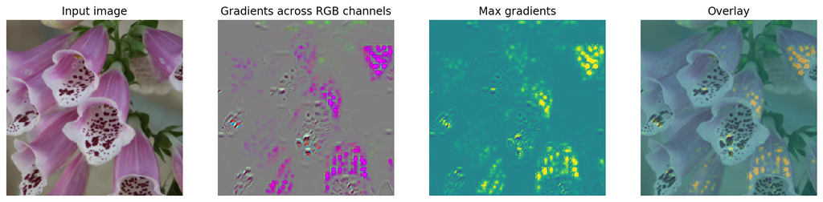

```python
backprop = Backprop(untuned_model)

backprop.visualize(foxglove, class_index, guided=True)
```

The network doesn't really know what to look for.  
After training, the tuned model achieved **>98%** test accuracy 🎉  
But *how*? What is it seeing now? 🤔

### Tuned model

Test accuracy: >98%

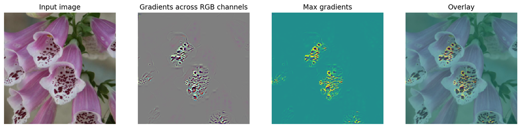

```python
backprop = Backprop(tuned_model)

backprop.visualize(foxglove, class_index, guided=True)
```

The model has *learnt* to focus on to the **most distinguising pattern**.  
*Show, don't tell* - visualization is a powerful tool.

## Let's make AI more explainable

With feature visualization, we're better equipped to:

- Focus on the *mechanisms* of how & what neural nets learn
- *Diagnose* what and why the network gets things wrong
- *Spot and correct* biases in algorithms

A step forward towards **understanding & trusting AI** 😌

## Thank you 🙏

- Checkout FlashTorch on [GitHub](https://github.com/MisaOgura/flashtorch)
- Try it out on [Google](https://colab.research.google.com/github/MisaOgura/flashtorch/blob/master/examples/visualize_saliency_with_backprop_colab.ipynb) [Colab](https://colab.research.google.com/github/MisaOgura/flashtorch/blob/master/examples/activation_maximization_colab.ipynb)
- [Suggestions & contributions](https://github.com/MisaOgura/flashtorch#how-to-contribute) welcome!

📡 Slide deck @ **tinyurl.com/flashtorch-wddconf**